# How do you stay fresh?

## The Challenge

- Unilever want to understand how consumers use deodorant.
- Experimental participants are notoriously bad at filling in study diaries.
- Unilever developed data loggers to collect user data in a less intrusive and more reliable way.
- Can we learn how consumers use deodorant just using the logger data?

[figure not shown]

## The data loggers

- Event start time, end time and duration.
- X, y, z and sound time series for each event.
- High frequency (20 observations per second).
- Event class: "Application", "Movement", "Unknown".

[figure not shown]

## Initial results and problems

- Small, quality in-lab dataset.
- Some events were unusually long (>20 seconds).
- Only part of an event might actually be true deodorant application.

## Solution

- Split events up in to "chunks" of 2 seconds.
- Use Linear Discriminant Analysis to identify useful data features for classification.

[figure not shown]

## Applying this the full UK study

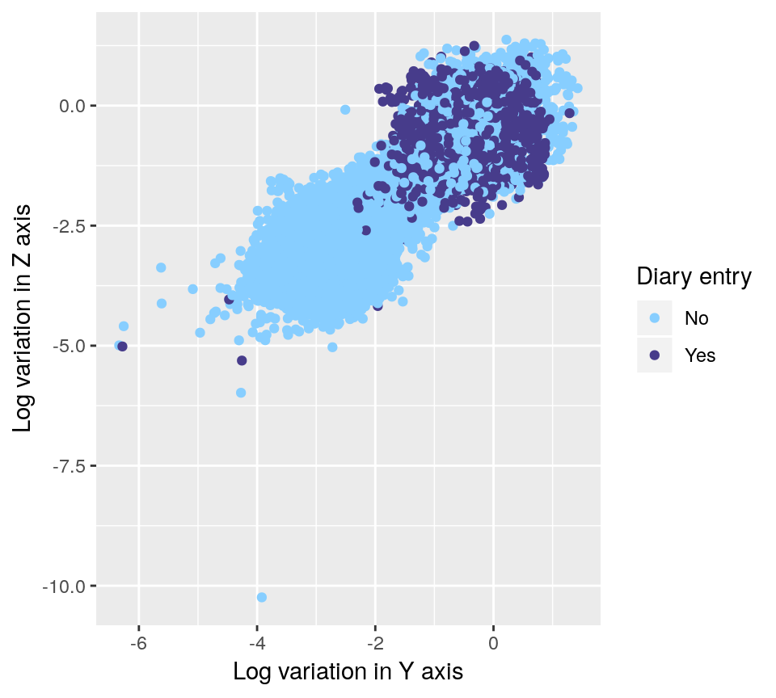

Movement is generally characterised by **low feature values**, and roll-on application is characterised by **high feature values**.

## Keep it simple!

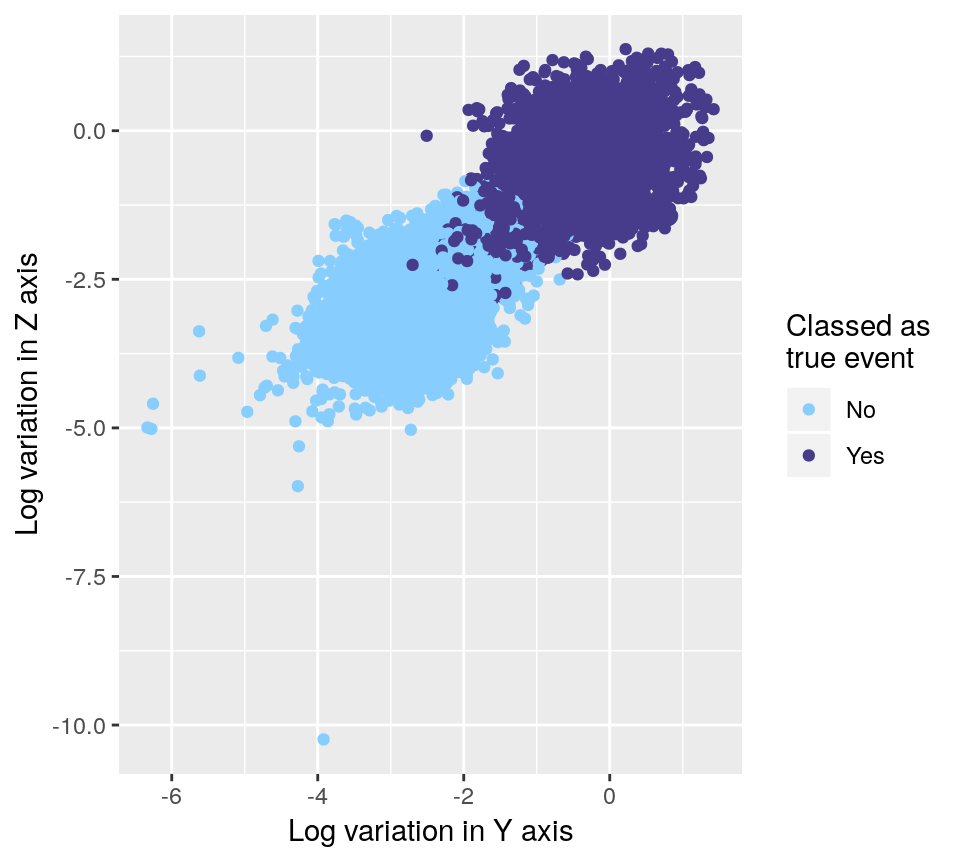

## Estimating activity duration

- We re-estimated event duration, excluding any 2 second chunks identified to be false applications.

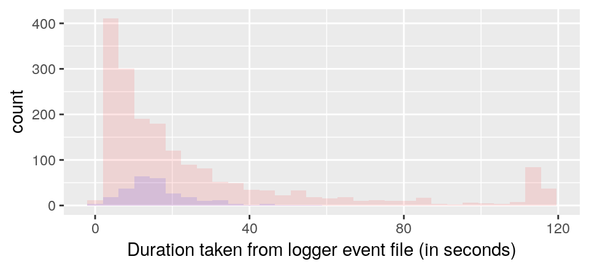

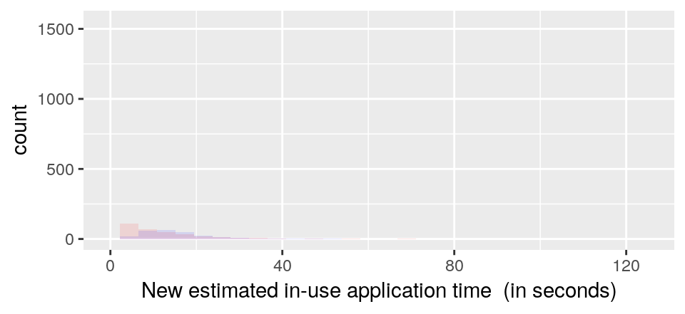

- Many non-diary events now have estimated duration of 0 seconds
- There are no longer any excessively long events.
- The average number of applications per day is now reasonable.

## User behaviour

- Once false positive activites have been removed we can look at user behaviour.

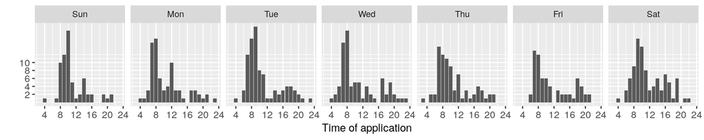

- The bars summarise the total number of applications made over the duration of the study split by hour of application and day of week.